# 算法训练营Day 40 - DP

Author

Siru Wu

Published

March 1, 2026

## [188.买卖股票的最佳时机IV](https://leetcode.cn/problems/best-time-to-buy-and-sell-stock-iv/description/)

> 给你一个整数数组 prices 和一个整数 k ，其中 prices[i] 是某支给定的股票在第 i 天的价格。

> 设计一个算法来计算你所能获取的最大利润。你最多可以完成 k 笔交易。也就是说，你最多可以买 k 次，卖 k 次。

> 注意：你不能同时参与多笔交易（你必须在再次购买前出售掉之前的股票）。

> **示例 1：**

> 输入：k = 2, prices = [2,4,1]

> 输出：2

> 解释：在第 1 天 (股票价格 = 2) 的时候买入，在第 2 天 (股票价格 = 4) 的时候卖出，这笔交易所能获得利润 = 4-2 = 2 。

> **示例 2：**

> 输入：k = 2, prices = [3,2,6,5,0,3]

> 输出：7

> 解释：在第 2 天 (股票价格 = 2) 的时候买入，在第 3 天 (股票价格 = 6) 的时候卖出, 这笔交易所能获得利润 = 6-2 = 4 。随后，在第 5 天 (股票价格 = 0) 的时候买入，在第 6 天 (股票价格 = 3) 的时候卖出, 这笔交易所能获得利润 = 3-0 = 3 。

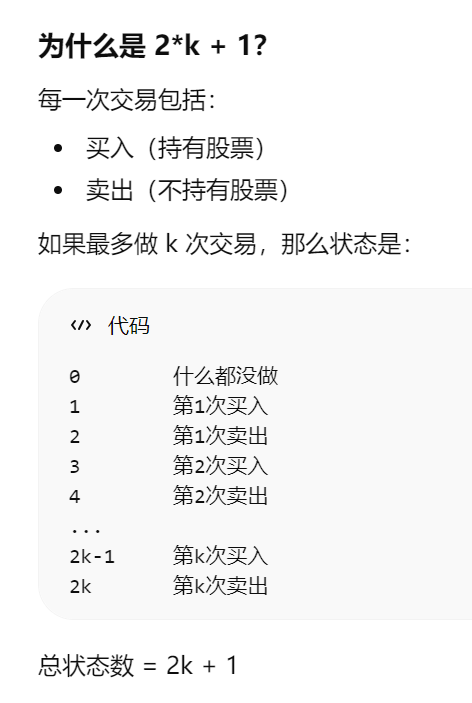

```python
class Solution:
    def maxProfit(self, k: int, prices: List[int]) -> int:
        if len(prices) == 0:
            return 0
        # 每一次交易包括：买入（持有股票）K + 卖出（不持有股票）K,加上第一天什么都没做的状态 0, 一共有2 * k + 1个状态
        dp = [[0] * (2*k + 1) for _ in range(len(prices))]
        for j in range(1, 2 * k, 2): # 奇数位置全是 买入位置
            dp[0][j] = -prices[0]
        for i in range(1, len(prices)):
            for j in range(0, 2 * k - 1, 2): # 因为我们要用到 j+2，所以 j 不能走到太后面
                # 买入 = max(昨天已经买了,昨天卖出后今天买)
                dp[i][j + 1] = max(dp[i - 1][j + 1], dp[i - 1][j] - prices[i]) # 买入状态转移
                # 卖出 = max(昨天已经卖了,昨天买入今天卖)
                dp[i][j + 2] = max(dp[i - 1][j + 2], dp[i - 1][j + 1] + prices[i]) #卖出状态转移
        return dp[-1][2 * k] # 最大利润一定是在：第 k 次卖出之后，也就是状态 2k
```

## [309.最佳买卖股票时机含冷冻期](https://leetcode.cn/problems/best-time-to-buy-and-sell-stock-with-cooldown/description/)

> 给定一个整数数组prices，其中第 prices[i] 表示第 i 天的股票价格 。

> 设计一个算法计算出最大利润。在满足以下约束条件下，你可以尽可能地完成更多的交易（多次买卖一支股票）:

> 卖出股票后，你无法在第二天买入股票 (即冷冻期为 1 天)。 注意：你不能同时参与多笔交易（你必须在再次购买前出售掉之前的股票）。

> **示例 1:**

> 输入: prices = [1,2,3,0,2]

> 输出: 3

> 解释: 对应的交易状态为: [买入, 卖出, 冷冻期, 买入, 卖出]

> **示例 2:**

> 输入: prices = [1]

> 输出: 0

```python
class Solution:
    def maxProfit(self, prices: List[int]) -> int:
        n = len(prices)
        if n == 0:
            return 0

        # 状态一：持有股票状态
        # 状态二：保持卖出股票的状态
        # 状态三：今天卖出股票
        # 状态四：今天为冷冻期状态

        dp = [[0] * 4 for _ in range(n)] # # 创建动态规划数组，4个状态分别表示持有股票、不持有股票且处于冷冻期、不持有股票且不处于冷冻期、不持有股票且当天卖出后处于冷冻期

        dp[0][0] = -prices[0] # # 初始状态：第一天持有股票的最大利润为买入股票的价格

        # 1. 达到买入股票状态（状态一）即：dp[i][0]，有两个具体操作
        # 1-1: 操作一：前一天就是持有股票状态（状态一）
        # 1-2: 操作二：今天买入了，有两种情况
        # 1-2-1: 前一天是冷冻期（状态四）
        # 1-2-2: 前一天是保持卖出股票的状态

        # 2. 达到保持卖出股票状态（状态二）即：dp[i][1]，有两个具体操作：
        # 2-1: 操作一：前一天就是状态二
        # 2-2: 操作二：前一天是冷冻期（状态四）

        # 3. 达到今天就卖出股票状态（状态三），即：dp[i][2] ，只有一个操作
        # 3-1: 昨天一定是持有股票状态（状态一），今天卖出

        # 4. 达到冷冻期状态（状态四），即：dp[i][3]，只有一个操作
        # 4-1: 昨天卖出了股票（状态三）
        for i in range(1, n):

            # 当前持有股票的最大利润等于前一天持有股票的最大利润或者前一天不持有股票且不处于冷冻期的最大利润减去当前股票的价格
            dp[i][0] = max(dp[i - 1][0], max(dp[i - 1][3], dp[i - 1][1]) - prices[i])

            # 当前不持有股票且处于冷冻期的最大利润等于前一天持有股票的最大利润加上当前股票的价格
            dp[i][1] = max(dp[i - 1][1], dp[i - 1][3])

            # 当前不持有股票且不处于冷冻期的最大利润等于前一天不持有股票的最大利润或者前一天处于冷冻期的最大利润
            dp[i][2] = dp[i - 1][0] + prices[i]

            # # 当前不持有股票且当天卖出后处于冷冻期的最大利润等于前一天不持有股票且不处于冷冻期的最大利润
            dp[i][3] = dp[i - 1][2]

        return max(dp[n - 1][3], dp[n - 1][2], dp[n - 1][1]) # 返回最后一天不持有股票的最大利润
```

## [714.买卖股票的最佳时机含手续费](https://leetcode.cn/problems/best-time-to-buy-and-sell-stock-with-transaction-fee/description/)

> 给定一个整数数组 prices，其中 prices[i]表示第 i 天的股票价格 ；整数 fee 代表了交易股票的手续费用。

> 你可以无限次地完成交易，但是你每笔交易都需要付手续费。如果你已经购买了一个股票，在卖出它之前你就不能再继续购买股票了。

> 返回获得利润的最大值。

> 注意：这里的一笔交易指买入持有并卖出股票的整个过程，每笔交易你只需要为支付一次手续费。

> **示例 1：**

> 输入：prices = [1, 3, 2, 8, 4, 9], fee = 2

> 输出：8

> 解释：能够达到的最大利润:

> 在此处买入 prices[0] = 1

> 在此处卖出 prices[3] = 8

> 在此处买入 prices[4] = 4

> 在此处卖出 prices[5] = 9

> 总利润: ((8 - 1) - 2) + ((9 - 4) - 2) = 8

> **示例 2：**

> 输入：prices = [1,3,7,5,10,3], fee = 3

> 输出：6

```python
class Solution:
    def maxProfit(self, prices: List[int], fee: int) -> int:
        dp = [[0] * 2 for _ in range(len(prices))]
        dp[0][0] = -prices[0]
        for i in range(1, len(prices)):
            # dp[i][0] 表示第i天持有股票所得最多现金
            #  dp[i][1] 表示第i天不持有股票所得最多现金
            dp[i][0] = max(dp[i - 1][0], dp[i - 1][1] - prices[i])
            dp[i][1] = max(dp[i - 1][1], dp[i - 1][0] + prices[i] - fee)
        return max(dp[-1][0], dp[-1][1])
```